# Aim2Lmers

AMS

2024-03-04

```r
library(tidyverse)
library(gazer)
library(readr)
library(lme4)
df = read_csv('gca_formatted_data.csv')
```

```
## ──────────────────────────────────────────────────────── Delimiter: "," chr
## (1): fixation_type dbl (7): ...1, participant, session, BIN_INDEX, sumFix,
## nTrials, meanFix
```

```r
summary(df)
```

```
##       ...1       participant        session    fixation_type
##  Min.   :   1   Min.   :308602   Min.   :1.0   Length:5016
##  1st Qu.:1255   1st Qu.:308613   1st Qu.:1.0   Class :character
##  Median :2508   Median :308621   Median :1.5   Mode  :character
##  Mean   :2508   Mean   :308620   Mean   :1.5
##  3rd Qu.:3762   3rd Qu.:308628   3rd Qu.:2.0
##  Max.   :5016   Max.   :308637   Max.   :2.0
##    BIN_INDEX         sumFix         nTrials         meanFix
##  Min.   : 0.00   Min.   : 0.00   Min.   : 9.00   Min.   :0.00000
##  1st Qu.:27.00   1st Qu.: 0.00   1st Qu.:46.00   1st Qu.:0.00000
##  Median :41.00   Median : 1.00   Median :52.50   Median :0.02128
##  Mean   :39.51   Mean   : 4.16   Mean   :46.32   Mean   :0.09037
##  3rd Qu.:55.00   3rd Qu.: 3.00   3rd Qu.:56.00   3rd Qu.:0.08511
##  Max.   :69.00   Max.   :48.00   Max.   :59.00   Max.   :0.91304
```

```r
df_gca <- code_poly(df, predictor = "BIN_INDEX", poly.order = 4) %>%
  mutate(Object = ifelse(fixation_type == 'unrelated', 'a_unrelated', fixation_type)) %>%
  mutate(session = factor(session)) %>%
  rename(subj = participant)
```

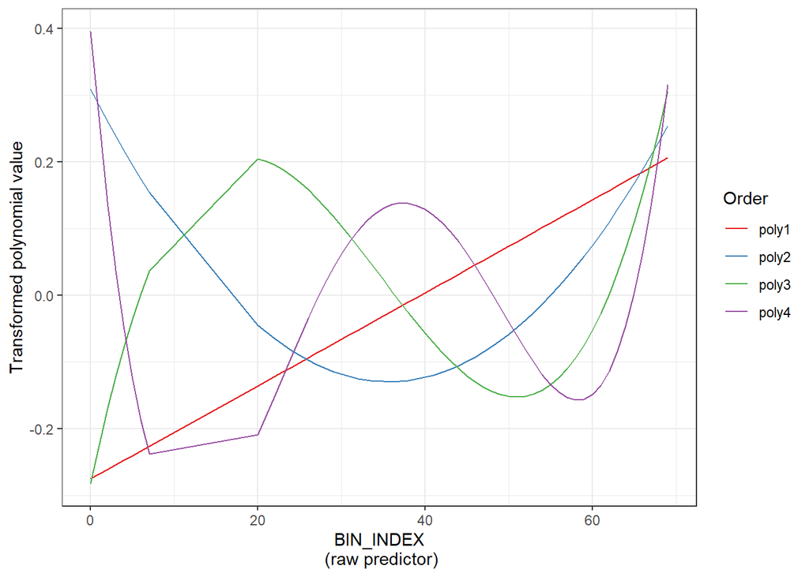

```r
m1 = lmer(meanFix~(poly1 + poly2) * Object * session + (poly1 + poly2 | subj) +
            (poly1 + poly2 | subj:Object),
            data=subset(df_gca),REML=F)
```

```
## boundary (singular) fit: see help('isSingular')
```

```r
summary(m1)
```

```
## Linear mixed model fit by maximum likelihood  ['lmerMod']
## Formula: meanFix ~ (poly1 + poly2) * Object * session + (poly1 + poly2 |
##     subj) + (poly1 + poly2 | subj:Object)
##    Data: subset(df_gca)
##
##      AIC      BIC   logLik deviance df.resid
## -12525.8 -12284.5   6299.9 -12599.8     4979
##
## Scaled residuals:
##     Min      1Q  Median      3Q     Max
## -4.6494 -0.3334 -0.0559  0.2569  7.3321
##
## Random effects:
##  Groups      Name        Variance Std.Dev. Corr
##  subj:Object (Intercept) 0.002845 0.05334
##              poly1       0.019754 0.14055  -0.45
##              poly2       0.064441 0.25385  -0.98  0.52
##  subj        (Intercept) 0.000000 0.00000
##              poly1       0.006240 0.07899    NaN
##              poly2       0.008717 0.09337    NaN -1.00
##  Residual                0.004414 0.06644
## Number of obs: 5016, groups:  subj:Object, 48; subj, 12
##
## Fixed effects:
##                                    Estimate Std. Error t value
## (Intercept)                        0.024148   0.015640   1.544
## poly1                             -0.061644   0.050933  -1.210
## poly2                             -0.025922   0.080729  -0.321
## Objectphonological                 0.002351   0.022117   0.106
## Objectsemantic                     0.029662   0.022117   1.341
## Objecttarget                       0.252499   0.022117  11.416
## session2                          -0.005901   0.003902  -1.512
## poly1:Objectphonological          -0.021408   0.064398  -0.332
## poly1:Objectsemantic              -0.129615   0.064398  -2.013
## poly1:Objecttarget                -0.185594   0.064398  -2.882
## poly2:Objectphonological           0.008301   0.107588   0.077
## poly2:Objectsemantic              -0.127521   0.107588  -1.185
## poly2:Objecttarget                -1.161742   0.107588 -10.798
## poly1:session2                     0.015220   0.029406   0.518
## poly2:session2                     0.002960   0.029110   0.102
## Objectphonological:session2       -0.002234   0.005512  -0.405
## Objectsemantic:session2           -0.010076   0.005512  -1.828
## Objecttarget:session2              0.005111   0.005512   0.927
## poly1:Objectphonological:session2 -0.003066   0.041546  -0.074
## poly1:Objectsemantic:session2      0.017664   0.041546   0.425
## poly1:Objecttarget:session2       -0.193443   0.041546  -4.656
## poly2:Objectphonological:session2  0.008884   0.040989   0.217
## poly2:Objectsemantic:session2      0.035280   0.040989   0.861
## poly2:Objecttarget:session2       -0.143402   0.040989  -3.499
```

```
##
## Correlation matrix not shown by default, as p = 24 > 12.
## Use print(x, correlation=TRUE)  or
##     vcov(x)        if you need it
```

```
## optimizer (nloptwrap) convergence code: 0 (OK)
## boundary (singular) fit: see help('isSingular')
```

### Interpreations

*Intercept*: The estimated baseline (intercept) when object is set to unrelated and session is set to 1. The p-value suggests this estimate is not statistically significant (p = 0.129).

*Main effects for Poly1 and Poly2*: We interpret the main effects for poly1 and poly2 at our reference value of object = ‘unrelated’. They do not show statistically significant effects on mean fixation (p = 0.232 and p = 0.749, respectively).

*Main effects for object relative to unrelated)*:

- Phonological: The effect of gazing at the phonological distractor as opposed to the unrelated distractor is not statistically significant (p = 0.916).
- Semantic: Similarly, the main effect of the semantic distractor does not significantly differ from unrelated effect (p = 0.186).
- Target: When participants gaze are the target fixation, there is a significant positive effect compared to “Unrelated” (p < 0.001), indicating a substantial increase in mean fixation for “Target” relative to “Unrelated”.

Session Effect: The main effect of session2 is not statistically significant (p = 0.131), suggesting no overall difference in the outcome variable between the sessions when not considering interactions.

Interactions with Poly1 and Poly2:

Poly1:Objectsemantic: Interaction between poly1 and being in the semantic distractor is significant (p = 0.049), suggesting the effect of poly1 on the outcome varies when comparing “Semantic” to “Unrelated”.

Poly1:Objecttarget: Similarly, the interaction between poly1 and target is significant (p = 0.006), indicating a different effect of poly1 in the “Target” condition relative to “Unrelated”.

Poly2:Objecttarget: The interaction between poly2 and target is highly significant (p < 0.001), showing a pronounced difference in the effect of poly2 for target compared to unrelated distractor.

Session Interactions:

Most interactions involving session2 are not statistically significant, indicating that the effects of Object categories and polynomial predictors do not differ significantly between sessions, with a few exceptions:

Objectsemantic:session2: Approaches significance (p = 0.068), suggesting a potential session-related difference in the semantic compared to the unrelated distractor, though not conventionally significant.

Poly1:Objecttarget:session2: Highly significant (p < 0.001), indicating a significant session-related difference in the effect of poly1 for the target location relative to the unrelated distractor.

Poly2:Objecttarget:session2: Also significant (p < 0.001), suggesting a significant session-related difference in the effect of poly2 for the target relative to unrelatd distractor.